# Data Analysis Report On We Rate Dogs

WeRateDogs is a Twitter account that rates people's dogs with a humorous comment about the dog. The account was started in 2015 by college student Matt Nelson, and has received international media attention both for its popularity and for the attention drawn to social media copyright law when it was suspended by Twitter for breaking these aforementioned laws.

This report documents on the analysis carried out on the data having successfully wrangled the data with the aim of gaining insights and finding relationships between variable.

[figure not shown]

[figure not shown]

## ANALYSIS AND VISUALIZATION

### Source Distribution

```python
"""
TweetDeck               10
Twitter Web Client      28
Twitter for iPhone    1855
Name: source, dtype: int64
"""
```

```
'\nTweetDeck               10\nTwitter Web Client      28\nTwitter for iPhone    1855\nName: source, dtype: int64\n'
```

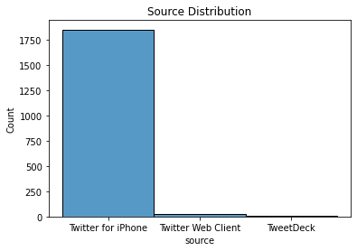

*Twitter for Iphone happens to contribute to over 85% of source*

### What relationship does retweet count and favourite count pose?

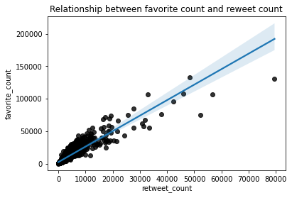

*Both variable tend to be positively correlated with each other*

### Check for performance of each model

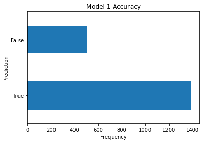

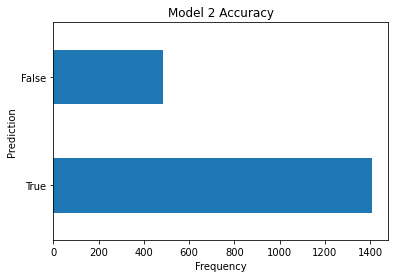

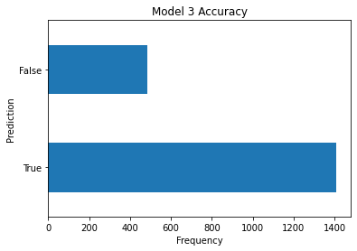

*All three model appears to perform with an accuracy of around 70% or higher*

## References

- https://en.wikipedia.org/wiki/WeRateDogs